# Novoalign Testing Report

18 August, 2016

## Introduction

- INTRODUCTION
  - NOVOALIGN = using the genome indexing tools
  - BWA = using BWT(Burrows-Wheeler Transform)
  - The table show the the number of mapped region/basepair based on the each chromosome that is including the PT(plasmid),MT(mitochondria),chr1-5(chromosome 1-5)
  - Each chromosome was obtained by using the SAMTOOLS from the sorted BAM file file to get each of chromosome by using the command
    - samtools view in.bam chr1 -b > out.bam (getting the chromosome 1)
  - The merge of each chromosome from ART and aligner was done by using the perl (perl scriptome)
  - The comparision was done by merge the SAM file from the ART with the Aligner SAM file by using perl based on the same basepair ID.
  - The the number lines is find the calculate the number of Basepair ID that. 1 basepair ID = 1 lines
  - The percent is calculate based on the SAM file from ART (it mapped 100%)
  - The unmapped from ART meaning the aligner has not been able to mapped that region/basepair to the reference sequence
  - The different chromosome meaning that the aligner has mapped to the diffrent chromosome than the SAM file from ART (based on the same basepair ID)
  - The start and stop position for above 50 or below -50 meaning the aligner has mapped outside the acceptable range based on the length of basepair been stimulate from ART(100bp)
  - The basepair that within the acceptable range meaning the aligner has mapped within the the acceptable range of basepair range based on the length of basepairs (100bp)
  - The basepair that have start and stop position exectly 0 meaning the aligner has mapped exectly same as ART

## TABLE FOR EACH CHROMOSOME

### NOVA LINES (NOVO T-154)

[output not shown]

### NOVA PERCENT (NOVO T-154)

| NOVOALIGN | pt | mt | chr1 | chr2 | chr3 | chr4 | chr5 |
| --- | --- | --- | --- | --- | --- | --- | --- |
| MAPPED according to ART | 99.611 | 68.487 | 99.348 | 98.735 | 99.335 | 99.339 | 99.389 |
| Start & stop basepairs location >50 | 8.277 | 1.058 | 1.063 | 0.348 | 0.483 | 0.660 | 0.778 |
| Start & Stop basepair location <50 | 8.070 | 1.180 | 1.063 | 0.349 | 0.484 | 0.651 | 0.779 |
| basepair that within the acceptable range | 83.264 | 66.250 | 97.228 | 98.038 | 98.368 | 98.028 | 97.832 |
| the basepairs location same as ART | 96.803 | 96.729 | 96.677 | 96.689 | 96.677 | 96.665 | 94.577 |

### BWA LINES (BWA I-7)

| BWA | pt | mt | chr1 | chr2 | chr3 | chr4 | chr5 |
| --- | --- | --- | --- | --- | --- | --- | --- |
| ART | 15440 | 36690 | 3026098 | 1969485 | 2344726 | 1858165 | 2696289 |
| alinger | 15431 | 36858 | 3025208 | 1968876 | 2344531 | 1857854 | 2695452 |
| Mapped according to ART | 15379 | 25443 | 3005521 | 1943823 | 2328592 | 1845238 | 2679062 |
| Start & Stop basepaired location >50 | 1278 | 379 | 31948 | 6877 | 11462 | 12288 | 20934 |
| Start & Stop basepaired location <50 | 1285 | 403 | 32087 | 6978 | 11427 | 12161 | 21224 |
| basepair location that within the acceptable range | 12816 | 24661 | 2941486 | 1929968 | 2305703 | 1820834 | 2636904 |
| The basepair location that same as ART | 12816 | 24660 | 2941428 | 1929942 | 2305665 | 1820815 | 2636865 |

### BWA PERCENT (BWA I-7)

| BWA | pt | mt | chr1 | chr2 | chr3 | chr4 | chr5 |
| --- | --- | --- | --- | --- | --- | --- | --- |
| Mapped according to ART | 99.605 | 69.3459 | 99.320 | 98.697 | 99.312 | 99.304 | 99.361 |
| Start and stop basepair location >50 | 8.277 | 1.0330 | 1.056 | 0.349 | 0.489 | 0.661 | 0.776 |
| Start and Stop basepair location <50 | 8.323 | 1.0980 | 1.060 | 0.354 | 0.487 | 0.654 | 0.787 |
| Basepairs location that within the acceptable range | 83.005 | 67.2140 | 97.204 | 97.994 | 98.336 | 97.991 | 97.798 |
| The basepaired location that same as ART | 83.005 | 99.9960 | 99.998 | 99.999 | 99.998 | 99.999 | 99.999 |

### Comparision between NOVO and BWA In percentage based on full Genome

| type | X90 | X100 | X110 | X154 | bwa7 |
| --- | --- | --- | --- | --- | --- |
| mapped according to ART | 99.98 | 99.99 | 100.00 | 100.00 | 100.00 |
| different chromosome than ART | 0.84 | 0.84 | 0.84 | 0.84 | 0.85 |
| Start and stop basepaired location> 50 | 0.71 | 0.71 | 0.71 | 0.71 | 0.71 |
| Start and stop basepaired location <50 | 0.71 | 0.71 | 0.71 | 0.71 | 0.72 |
| The same basepair location as the ART | 94.48 | 94.48 | 94.48 | 94.48 | 97.70 |

### Comparision between NOVO(N) and BWA(B) in percentage based on each Chromosome

| Chromosome | Npt | Bpt | Nmt | Bmt | Nchr1 | Bchr1 | Nchr2 | Bchr2 | Nchr3 | Bchr3 | Nchr4 | Bchr4 | Nchr5 | Bchr5 |
| --- | --- | --- | --- | --- | --- | --- | --- | --- | --- | --- | --- | --- | --- | --- |
| alinger | 99.916 | 99.942 | 99.275 | 100.4580 | 100.000 | 99.971 | 100.010 | 99.969 | 100.009 | 99.992 | 100.005 | 99.983 | 99.986 | 99.969 |
| Mapped according to ART | 99.611 | 99.605 | 68.487 | 69.3459 | 99.348 | 99.320 | 98.735 | 98.697 | 99.335 | 99.312 | 99.339 | 99.304 | 99.389 | 99.361 |
| Start & stop basepairs location >50 | 8.277 | 8.277 | 1.058 | 1.0330 | 1.063 | 1.056 | 0.348 | 0.349 | 0.483 | 0.489 | 0.660 | 0.661 | 0.778 | 0.776 |
| Start & Stop basepairs location <50 | 8.070 | 8.323 | 1.180 | 1.0980 | 1.063 | 1.060 | 0.349 | 0.354 | 0.484 | 0.487 | 0.651 | 0.654 | 0.779 | 0.787 |
| Basepairs location within the acceptable range | 83.264 | 83.005 | 66.250 | 67.2140 | 97.228 | 97.204 | 98.038 | 97.994 | 98.368 | 98.336 | 98.028 | 97.991 | 97.832 | 97.798 |
| Basepair that same location to the ART | 96.803 | 83.005 | 96.729 | 99.9960 | 96.677 | 99.998 | 96.689 | 99.999 | 96.677 | 99.998 | 96.665 | 99.999 | 94.577 | 99.999 |

### Comparision between BWA and multiple Novo in number of Lines

| V1 | V2 | V3 | V4 | V5 | V6 | V7 | V8 | V9 |
| --- | --- | --- | --- | --- | --- | --- | --- | --- |
| type | 90full | 90pt | 90mt | 90chr1 | 90chr2 | 90chr3 | 90chr4 | 90chr5 |
| art | 11946893 | 15440 | 36690 | 3026098 | 1969485 | 2344726 | 1858165 | 2696289 |
| align | 11945082 | 15424 | 36416 | 3025666 | 1969382 | 2344618 | 1858001 | 2695575 |
| Merge of art and align | 11945082 | 15377 | 25125 | 3005947 | 1944276 | 2328829 | 1845618 | 2679465 |
| type | 100full | 100pt | 100mt | 100chr1 | 100chr2 | 100chr3 | 100chr4 | 100chr5 |
| art | 11946893 | 15440 | 36690 | 3026098 | 1969485 | 2344726 | 1858165 | 2696289 |
| align | 11946255 | 15427 | 36422 | 3025975 | 1969578 | 2344864 | 1858188 | 2695801 |
| merge of art and align | 11945082 | 15380 | 25127 | 3006245 | 1944474 | 2329074 | 1845807 | 2679702 |
| type | 110full | 110pt | 110mt | 110chr1 | 110chr2 | 110chr3 | 110chr4 | 110chr5 |
| art | 11946893 | 15440 | 36690 | 3026098 | 1969485 | 2344726 | 1858165 | 2696289 |
| align | 11946616 | 15427 | 36424 | 3026070 | 1969644 | 2344930 | 1858248 | 2695873 |
| merge of art and align | 11946616 | 15380 | 25128 | 3006340 | 1944537 | 2329138 | 1845868 | 2679772 |
| type | 154full | 154pt | 154mt | 154chr1 | 154chr2 | 154chr3 | 154chr4 | 154chr5 |
| art | 11946893 | 15440 | 36690 | 3026098 | 1969485 | 2344726 | 1858165 | 2696289 |
| align | 11946770 | 15427 | 36424 | 3026110 | 1969673 | 2344963 | 1858267 | 2695906 |
| merge of art and align | 11946770 | 15380 | 25128 | 3006380 | 1944562 | 2329171 | 1845886 | 2679804 |
| type | 7full | 7pt | 7mt | 7chr1 | 7chr2 | 7chr3 | 7chr4 | 7chr5 |
| art | 11947054 | 15440 | 36690 | 3026098 | 1969485 | 2344726 | 1858165 | 2696289 |
| align | 11946918 | 15431 | 36858 | 3025208 | 1968876 | 2344531 | 1857854 | 2695452 |
| merge of art and align | 11946918 | 15379 | 25443 | 3005521 | 1943823 | 2328592 | 1845238 | 2679062 |

### Comparision between BWA and multiple Novo (Percent)

[output not shown]

### Comparision between BWA and multiple Novo Full (Percent)

| type | N90full | N100full | N110full | N154full | B7full |
| --- | --- | --- | --- | --- | --- |
| The same basepair ID with ART | 99.98 | 99.98 | 100 | 100 | 100 |

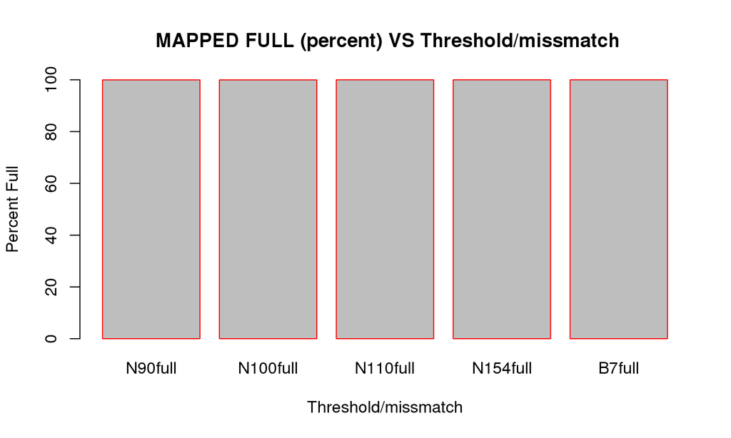

### Comparision between BWA and multiple Novo PT (Percent)

[output not shown]

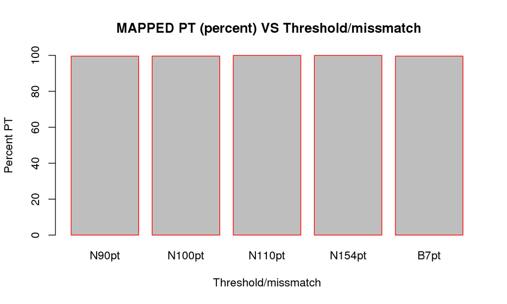

### Comparision between BWA and multiple Novo MT (Percent)

| type | N90mt | N100mt | N110mt | N154mt | B7mt |
| --- | --- | --- | --- | --- | --- |
| Same basepair ID with ART | 68.48 | 68.48 | 68.49 | 68.49 | 69.35 |

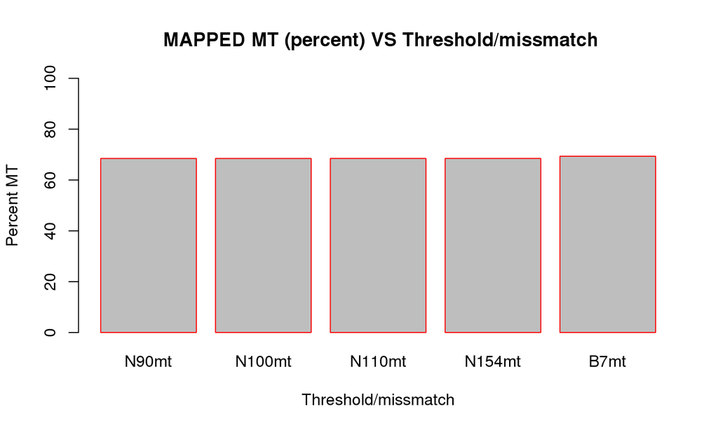

### Comparision between BWA and multiple Novo CHR1 (Percent)

| type | N90chr1 | N100chr1 | N110chr1 | N154chr1 | B7chr1 |
| --- | --- | --- | --- | --- | --- |
| Same Basepair ID with ART | 99.33 | 99.34 | 99.35 | 99.35 | 99.32 |

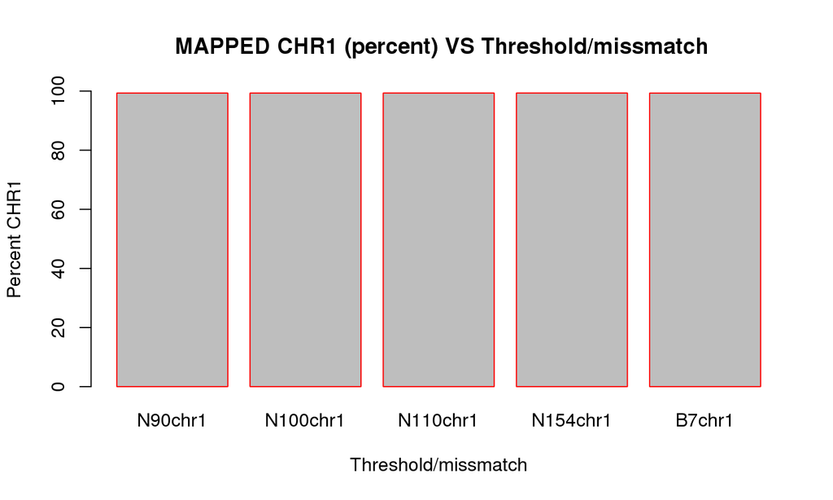

### Comparision between BWA and multiple Novo CHR2 (Percent)

| type | N90chr2 | N100chr2 | N110chr2 | N154chr2 | B7chr2 |
| --- | --- | --- | --- | --- | --- |
| Same Basepaired ID with ART | 98.72 | 98.73 | 98.73 | 98.73 | 98.7 |

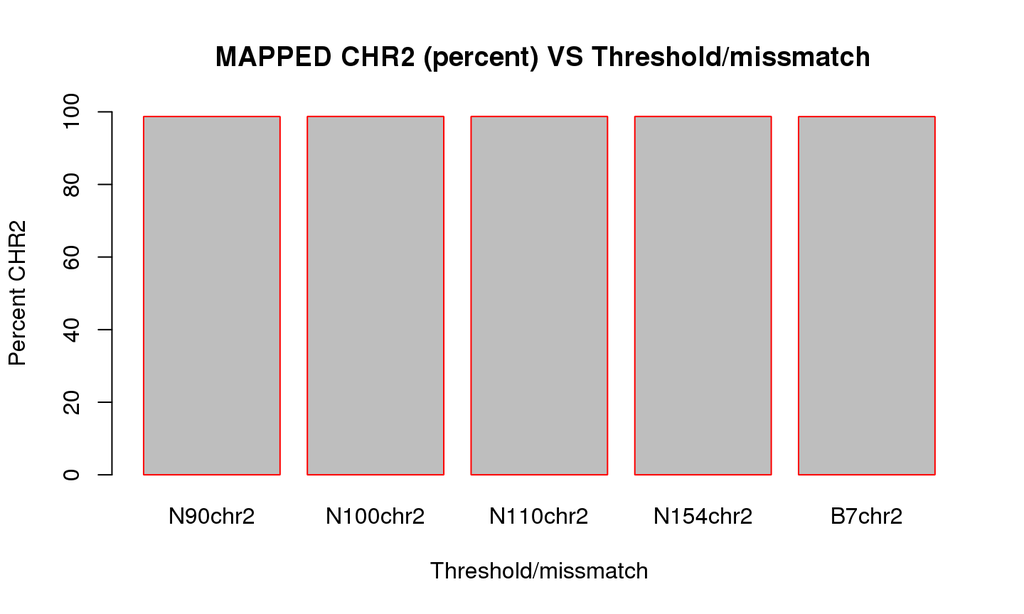

### Comparision between BWA and multiple Novo CHR3 (Percent)

[output not shown]

[figure not shown]

### Comparision between BWA and multiple Novo CHR4 (Percent)

| type | N90chr4 | N100chr4 | N110chr4 | N154chr4 | B7chr4 |
| --- | --- | --- | --- | --- | --- |
| Same Basepaired ID with ART | 99.32 | 99.33 | 99.34 | 99.34 | 99.3 |

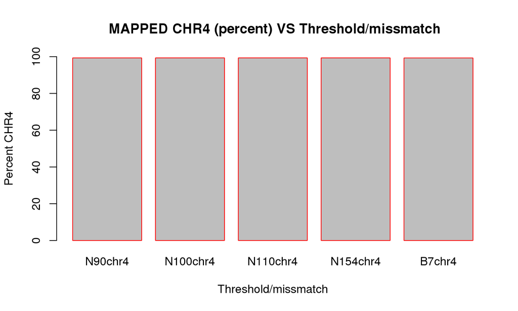

### Comparision between BWA and multiple Novo CHR5 (Percent)

| type | N90chr5 | N100chr5 | N110chr5 | N154chr5 | B7chr5 |
| --- | --- | --- | --- | --- | --- |
| Same Basepaired ID with ART | 99.38 | 99.38 | 99.39 | 99.39 | 99.36 |

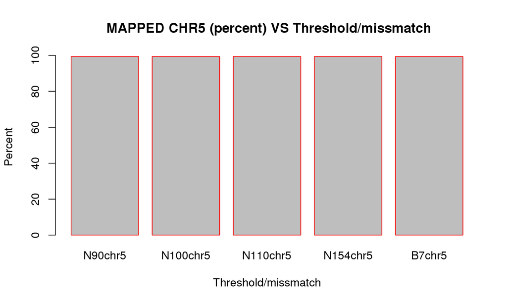

### VennDiagram

##### the acceptable basepair location based on the merge with ART (No of LINES)

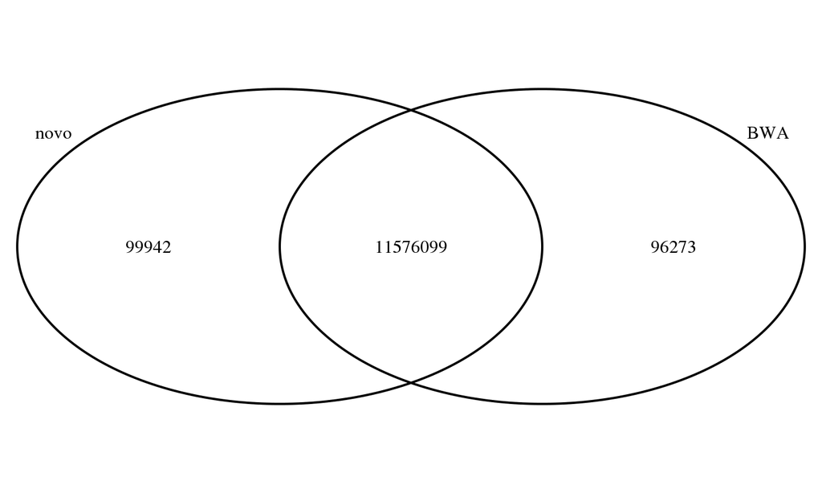

##### the percentage of the accetable basepair location

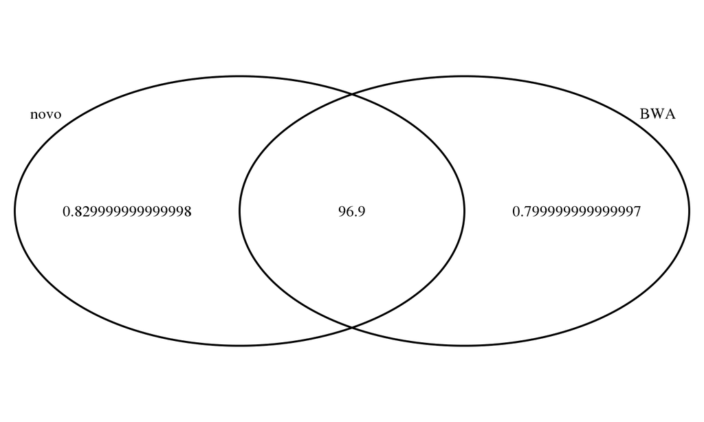

##### the acceptable basepair location based on the merge with ART (No of LINES)

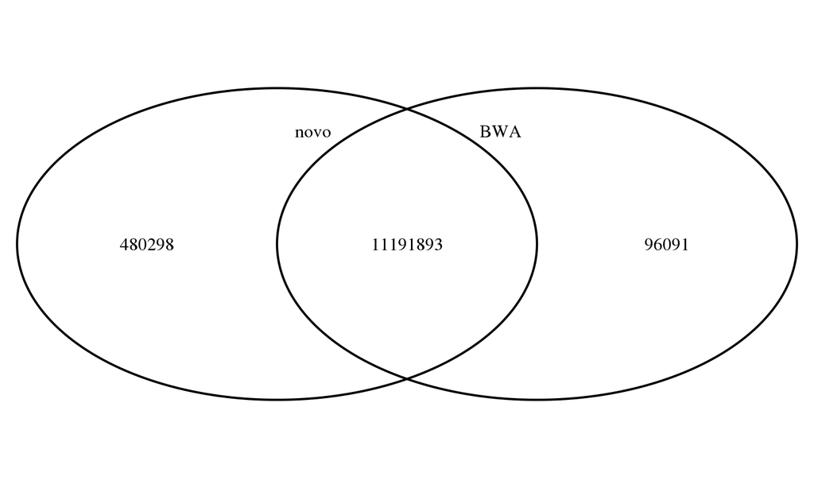

##### the percentage of the accetable basepair location

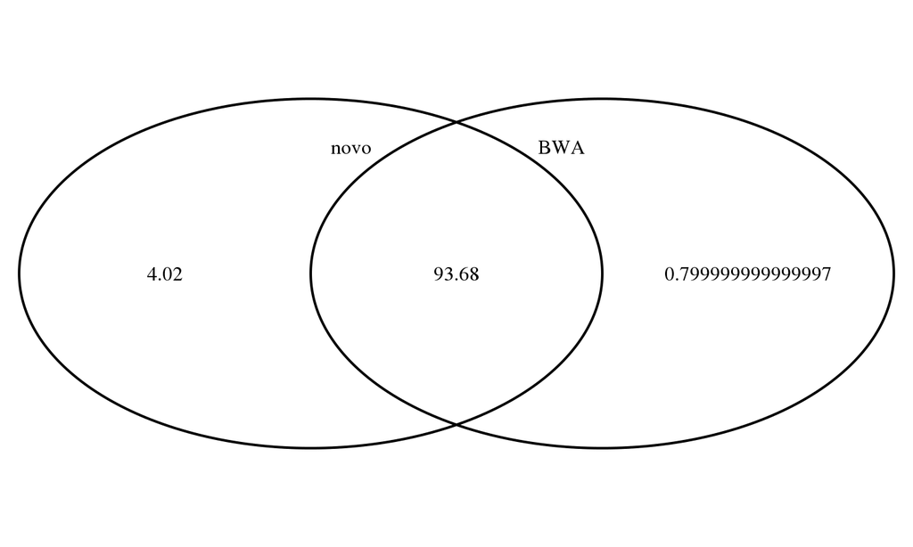